# Project 2

Navruzbek Karamatov

March 11, 2019

## Credit card transactions

Initially, important libraries are called.

```r
library(lubridate)
library(dplyr)
```

First, raw data is imported and extracted column names.

```r
mydata=read.csv("C:/Users/navruzbek/Desktop/r_projects/stock return data analysis/res_purchase_2014.csv",sep=",", dec=".", stringsAsFactors=FALSE, header=TRUE)
names(mydata)
```

```
 [1] "Year.Month"                   "Agency.Number"
 [3] "Agency.Name"                  "Cardholder.Last.Name"
 [5] "Cardholder.First.Initial"     "Description"
 [7] "Amount"                       "Vendor"
 [9] "Transaction.Date"             "Posted.Date"
[11] "Merchant.Category.Code..MCC."
```

Now data should be cleaned before any analysis.

Extra letters should be removed from column that holds transaction amount. Moreover, “(” sign is replaced by “-”.

```r
mydata$Amount2 = gsub("[)$a-z]", "", as.character(mydata$Amount))
mydata$Amount2 = gsub("[(]", "-", as.character(mydata$Amount2))
```

Sum of total spending is obtained.

```r
sum(as.numeric(as.character(mydata$Amount2)))
```

```
[1] 188040606
```

Now sum of total spending at “WW GRAINGER” is obtained.

```r
newdata = mydata[which(mydata[,8] == "WW GRAINGER"),]
sum(as.numeric(as.character(newdata$Amount2)))
```

```
[1] 5089417
```

Also, sum of total spending at “WM SUPERCENTER” is obtained.

```r
newdata = mydata[which(mydata[,8] == "WM SUPERCENTER"),]
sum(as.numeric(as.character(newdata$Amount2)))
```

```
[1] 31777.83
```

Now standard deviation of monthly spending is obtained. First month and year information is extracted from data.

```r
dates = mdy_hm((mydata[,9]))
mymonth = unique(month(dates))
myyear = unique(year(dates))
mydata$year = year(dates)
mydata$month = month(dates)
```

Then, by rolling over months and years, total monthly spending is obtained.

```r
monthlysum=list()
for(i in 1:2){
  AA = myyear[i]
  for(n in 1:length(mymonth)){
    BB = mymonth[n]
    newdata <- as.data.frame(mydata[ which( mydata[,13] == AA & mydata[,14] == BB), ])
    monthlysum[length(monthlysum)+1] = sum(as.numeric(as.character(newdata$Amount2)))
  }
}
```

standard deviation of monthly spending is given below.

```r
monthlysum=as.numeric(monthlysum)
monthlysum = monthlysum[monthlysum > 0 ]
sd(monthlysum)
```

```
[1] 5642406
```

### Extra analysis of credit card transactions data

#### Average transaction by vendors’ name and category

Here, credit card data is further analyzed by getting the mean of transaction for each vendor name.

By looping through the names of vendors, average transactions are obtained.

```r
vendor_list = unique(mydata[,8])
spending_by_vendor=list()
for(i in 1:length(vendor_list)){
  vendor_name = vendor_list[i]
  temp_data = mydata[which(mydata[,8] == vendor_name),]
  spending_by_vendor[length(spending_by_vendor)+1]=
    mean(as.numeric(as.character(temp_data$Amount2)), na.rm=TRUE)
}
```

```r
spending_by_vendor = as.numeric(spending_by_vendor)
length(vendor_list)
```

```
[1] 86727
```

A number of vendors is very big, thus, it takes a little bit time to get the average of transactions for every vendor.

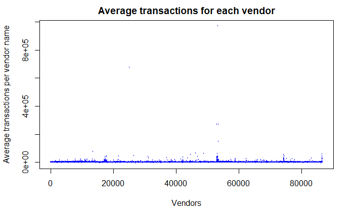

```r
plot(spending_by_vendor, ylab='Average transactions per vendor name', xlab='Vendors',
     main = "Average transactions for each vendor",cex=0.3, col='blue')
```

Clearly data has outliers as displayed by a plot. Some vendors experienced very high transactions.

```r
spending_by_vendor_sorted = sort(spending_by_vendor,decreasing = TRUE)
spending_by_vendor_sorted[1:10]
```

```
 [1] 972261.50 676960.09 270669.24 269333.12 149500.00  75393.94  65882.75  63959.00  62330.14
[10]  57835.05
```

To get the category names of those vendors, data looped again to obtain category names for top 100 vendors only. Categories of vendors that experienced very high trasactions are given below.

```r
category_type = list()
for(i in 1:100){
  vendor_name = vendor_list[which(spending_by_vendor %in% spending_by_vendor_sorted[i])]
  if(length(vendor_name) > 1){vendor_name = vendor_name[1]}
  temp_data = mydata[which(mydata[,8] == vendor_name),]
  category_type[length(category_type)+1] = temp_data[1,11]
}
category_type=as.character(category_type)
category_type[1:5]
```

```
[1] "COMMERCIAL EQUIPMENT, NOT ELSEWHERE CLASSIFIED"
[2] "OTHER FEES"
[3] "GENERAL CONTRACTORS-RESIDENTIAL AND COMMERCIAL"
[4] "COMPUTERS, COMPUTER PERIPHERAL EQUIPMENT, SOFTWARE"
[5] "COMMERCIAL EQUIPMENT, NOT ELSEWHERE CLASSIFIED"
```

Next, frequency of categories is investigated in order to investigate the most frequent categories.

```r
freq.table = table(category_type)
freq.table = freq.table[order(freq.table, decreasing=T)]
freq.table[1:6]
```

```
category_type
         COMMERCIAL EQUIPMENT, NOT ELSEWHERE CLASSIFIED
                                                     10
                      MISCELLANEOUS GENERAL MERCHANDISE
                                                     10
DENTAL/LABORATORY/MEDICAL/OPHTHALMIC HOSP EQIP AND SUP.
                                                      8
                                     SOUTHWEST AIRLINES
                                                      8
           INDUSTRIAL SUPPLIES NOT ELSEWHERE CLASSIFIED
                                                      7
             BUSINESS SERVICES NOT ELSEWHERE CLASSIFIED
                                                      5
```

Clearly, customers spent huge amount of money especially in vendors operating in commerical equipment, general merchandise and dental categories.

Now, data is checked again for negative average transactions.

```r
spending_by_vendor_sorted = sort(spending_by_vendor,decreasing = FALSE)
spending_by_vendor_sorted[1:10]
```

```
 [1] -4907.220 -4454.760 -3537.900 -3047.263 -2957.000 -2399.600 -2188.000 -2084.520 -2000.000
[10] -1900.870
```

Now, category names are obtained again for top 100 vendors with negative average transactions.

```r
category_type = list()
for(i in 1:100){
  vendor_name = vendor_list[which(spending_by_vendor %in% spending_by_vendor_sorted[i])]
  if(length(vendor_name) > 1){vendor_name = vendor_name[1]}
  temp_data = mydata[which(mydata[,8] == vendor_name),]
  category_type[length(category_type)+1] = temp_data[1,11]
}
category_type=as.character(category_type)
category_type[1:5]
```

```
[1] "BOOK STORES"
[2] "MISCELLANEOUS AND SPECIALTY RETAIL STORES"
[3] "HOBBY,TOY,AND GAME STORES"
[4] "USED MERCHANDISE AND SECONDHAND STORES"
[5] "DIRCT MARKETING/DIRCT MARKETERS--NOT ELSEWHERE CLASSIFIED"
```

Next, the frequency of categories is further investigated.

```r
freq.table = table(category_type)
freq.table = freq.table[order(freq.table, decreasing=T)]
freq.table[1:6]
```

```
category_type
                         AMERICAN AIRLINES                         SOUTHWEST AIRLINES
                                        36                                          6
STATIONERY,OFFICE AND SCHOOL SUPPLY STORES                            UNITED AIRLINES
                                         6                                          6
                         CATALOG MERCHANTS                                      DELTA
                                         5                                          3
```

Airlines are in top 6 categories where customers became indebted for transactions. Obviously, it happaned when customers were purchasing airplane tickets.

#### Total transactions by cardholders’ last name

Next, total transactions by cardholders’ last name is analyzed. However, data contains unreal cardholder names and they are dropped first.

```r
mydata$Cardholder.Last.Name2 = gsub("[0-9]", NA, as.character(mydata$Cardholder.Last.Name))
mydata$Cardholder.Last.Name2 = tolower(mydata$Cardholder.Last.Name2)
mydata$Cardholder.Last.Name2 = gsub("cardholder",
                                    NA,as.character(mydata$Cardholder.Last.Name2))
```

Folowing the cleansing, unique names are obtained and looped through the data to get the sum of transactions for each cardholder’s last name.

```r
card_holder_name = unique(mydata$Cardholder.Last.Name2)
card_holder_name = na.omit(card_holder_name)
spending_by_card_holder_name=list()
for(i in 1:length(card_holder_name)){
  card_name = card_holder_name[i]
  temp_data = mydata[which(mydata$Cardholder.Last.Name2 == card_name),]

  spending_by_card_holder_name[length(spending_by_card_holder_name)+1]=
    sum(as.numeric(as.character(temp_data$Amount2)), na.rm=TRUE)
}
spending_by_card_holder_name = as.numeric(spending_by_card_holder_name)
```

First, top 10 customers with the smallest transactions are shown.

```r
spending_by_card_holder_name_sorted = sort(spending_by_card_holder_name, decreasing = FALSE)
card_holder_name[which(spending_by_card_holder_name %in%
                         spending_by_card_holder_name_sorted[1:10])]
```

```
 [1] "speight"  "damron"   "cotts"    "smalling" "hodgson"  "mackie"   "shockley" "cauthron"
 [9] "yip ch"   "keenan"   "leas"
```

Next, top 10 customers with the highest transactions are shown.

```r
spending_by_card_holder_name_sorted = sort(spending_by_card_holder_name, decreasing = TRUE)
card_holder_name[which(spending_by_card_holder_name %in%
                         spending_by_card_holder_name_sorted[1:10])]
```

```
 [1] "hines"                    "cantrell"                 "johnson"
 [4] "larson"                   "lewis"                    "mccall"
 [7] "saltzman"                 "journey house travel inc" "university american"
[10] "stroup"
```

Interestingly, not all customers are individuals but includes institutions as well, such as “journey house travel inc”.

#### Average transactions by category name

Next, I looked at the average transaction made for each category name.

```r
category_list = unique(mydata[,11])
length(category_list)
```

```
[1] 435
```

```r
spending_by_category=list()
for(i in 1:length(category_list)){
  category_name = category_list[i]
  temp_data = mydata[which(mydata[,11] == category_name),]
  spending_by_category[length(spending_by_category)+1]=
    mean(as.numeric(as.character(temp_data$Amount2)), na.rm=TRUE)
}
spending_by_category = as.numeric(spending_by_category)
```

From plot it is clear that majority of average transactions for categories are below 1000.

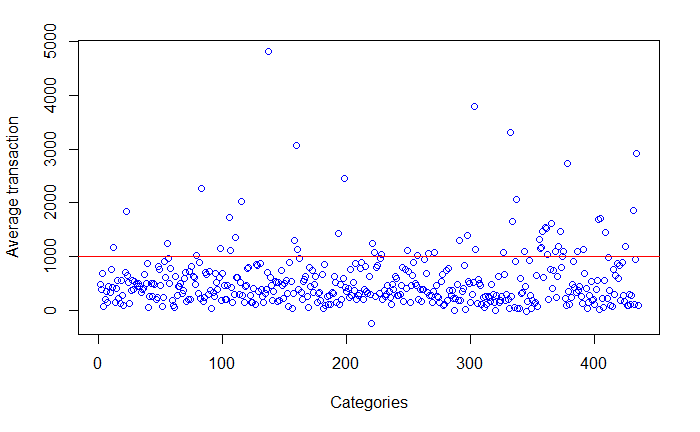

```r
plot(spending_by_category, col='blue', xlab='Categories', ylab='Average transaction')
abline(h = 1000, col='red')
```

Now checked categories that received small transactions on average

```r
#small transactions made
spending_by_category_sorted = sort(spending_by_category,decreasing = FALSE)
spending_by_category_sorted[1:20]
```

```
 [1] -243.00733  -18.45667    0.00000    0.00000   20.97000   20.99333   25.67500   27.12000
 [9]   28.91750   30.77576   32.92343   35.00000   39.23667   40.00000   46.17314   46.61472
[17]   53.34751   53.74273   55.44333   57.00000
```

```r
category_list[which(spending_by_category %in%
                           spending_by_category_sorted[1:20])]
```

```
 [1] "RECORD STORES"
 [2] "COURIER SERVICES-AIR AND GROUND,AND FREIGHT FORWARDERS"
 [3] "AIRLINES AND AIR CARRIERS"
 [4] "TRAVEL AGENCIES"
 [5] "AUTOMATED FUEL DISPENSER"
 [6] "CAR WASHES"
 [7] "USED MERCHANDISE AND SECONDHAND STORES"
 [8] "EXTENDED STAY AMERICA"
 [9] "SHOE REPR SHPS,SHOE SHINE PARLRS,AND HAT CLEANING SHPS"
[10] "MOTEL 6"
[11] "LA QUINTA RESORT"
[12] "DIRECT MARKETING--INBOUND TELEMARKETING MERCHANTS"
[13] "KNIGHTS INN"
[14] "POLITICAL ORGANIZATIONS"
[15] "FREMONT HOTEL AND CASINO"
[16] "PRIMADONNA HOTEL AND CASINO"
[17] "MOBILE HOME DEALERS"
[18] "AMBULANCE SERVICES"
[19] "PAWN SHOPS"
[20] "FINES"
```

Now checked categories that received big transactions on average

```r
#big transactions made
spending_by_category_sorted = sort(spending_by_category,decreasing = TRUE)
spending_by_category_sorted[1:20]
```

```
 [1] 4823.345 3797.920 3306.516 3071.505 2924.500 2739.213 2454.764 2270.057 2054.350 2031.120
[11] 1862.760 1833.503 1716.500 1710.683 1685.634 1651.828 1605.600 1534.357 1527.688 1473.688
```

```r
category_list[which(spending_by_category %in%
                      spending_by_category_sorted[1:20])]
```

```
 [1] "COMPUTERS, COMPUTER PERIPHERAL EQUIPMENT, SOFTWARE"
 [2] "COMPUTER MAINTENANCE, REPAIR AND SERVICES NOT ELSEWHERE CLAS"
 [3] "ELECTRICAL CONTRACTORS"
 [4] "PROTEA HOTELS"
 [5] "GENERAL CONTRACTORS-RESIDENTIAL AND COMMERCIAL"
 [6] "PETROLEUM AND PETROLEUM PRODUCTS"
 [7] "ARCHITECTURAL,ENGINEERING,AND SURVEYING SERVICES"
 [8] "WYNN LAS VEGAS"
 [9] "OTHER FEES"
[10] "HOTEL INDIGO GALLERIA HOUSTON"
[11] "CHILD CARE SERVICES"
[12] "AIR INDIA"
[13] "QUANTAS"
[14] "ETHIOPIAN AIRLINES"
[15] "AIR NEW ZEALAND LTD. INTERNATIONAL"
[16] "THUNDERBIRD/RED LION"
[17] "EASYJET"
[18] "MERIDIEN"
[19] "SILVER LEGACY HOTEL AND CASINO"
[20] "JAPAN AIR LINES"
```